# Guía Modelos Lineales Mixtos

Curso Introducción al Análisis de datos con R para la acuicultura

Dr. José A. Gallardo y Dra. María Angélica Rueda.

Pontificia Universidad Católica de Valparaíso  
jose.gallardo@pucv.cl

13 November 2021

### MODELOS LINEALES MIXTOS

Los modelos lineales mixtos (MLM) son una generalización del modelo lineal de regresión clásico, contemplando la posible existencia de observaciones correlacionadas (ej. Medidas repetidas en el mismo individuo) o con variabilidad heterogénea, vinculadas a la presencia de factores aleatorios.

**Efecto fijo**: Los efectos fijos solo estiman medias de las variables predictoras.

**Efecto aleatorio**: Los efectos aleatorios estiman varianzas.

Caracteristicas de un modelo lineal mixto (MLM)

1). El MLM está conformado por efectos fijos y efectos aleatorios.

2). La variable respuesta debe tener ditribución normal.

3). Existencia de observaciones correlacionadas.

4). Puede existir heterogeneidad de varianzas.

Incumplimiento de supuestos (1 y 3):

1. Hay observaciones correlacionadas.
2. Los residuos se distribuyen **normalmente**.
3. No hay homogeneidad de varianzas.

#### **Objetivos de aprendizaje**

Los objetivos de aprendizaje de esta guía son:

**1**. - Identificar efectos fijos y efectos aleatorios.

**3**. - Ajustar modelos lineales mixtos.

**3**. - Realizar gráficas avanzadas con ggplot2.

**4**. - Elaborar un reporte dinámico en formato pdf con **[Rmarkdown](https://rmarkdown.rstudio.com/)**.

## ESTUDIO DE CASO: PARGO NEGRO

En este estudio de caso trabajaremos con un set de datos de 120 observaciones simuladas de pargo negro, en las que se usó como referencia los valores presentados en el artículo. [Fuente: Kih Kim et.al 2018](https://fas.biomedcentral.com/articles/10.1186/s41240-017-0079-3)

### **Ejercicio 1.** Elaborar y configurar Reporte en formato .Rmd

Elabore un documento .Rmd y configure su reporte para exportar en .pdf. Instale solo las librerías que utilice para el análisis de los datos.

```r
knitr::opts_chunk$set(echo = TRUE)
library(readxl)
library(ggplot2)
library(dplyr)
library(multcomp)
library(psych)
library(car)
library(nlme)
library(lme4)
library(readr)
library(lmtest)
library(sjPlot)
```

Ejecute cada uno de los siguientes ejercicios en uno o más bloques de códigos diferentes. Sea ordenado y documente su reporte adecuadamente.

### **Ejercicio 2.** Exploratorio set de datos pargo_data.xlsx

Importe el set de datos **pargo_data.xlsx** y realice un análisis exploratorio de datos.

**a).** Resumen estadístico de todas las variables.

```r
pargo_data <- read_excel("pargo_data.xlsx")
summary(pargo_data)
```

```
##        ID            Family          Initial_Biomass_g Final_Biomass_g
##  Min.   :  1.00   Length:120         Min.   :25598     Min.   :28120
##  1st Qu.: 30.75   Class :character   1st Qu.:26186     1st Qu.:28723
##  Median : 60.50   Mode  :character   Median :26345     Median :28985
##  Mean   : 60.50                      Mean   :26426     Mean   :28999
##  3rd Qu.: 90.25                      3rd Qu.:26596     3rd Qu.:29258
##  Max.   :120.00                      Max.   :27778     Max.   :30152
##     Dosis               Tank
##  Length:120         Length:120
##  Class :character   Class :character
##  Mode  :character   Mode  :character
##
##
##
```

```r
pargo_data$Dosis <- as.factor(pargo_data$Dosis)
pargo_data$Tank <- as.factor(pargo_data$Tank)
pargo_data$Family <- as.factor(pargo_data$Family)
pargo_data$ID <- as.factor(pargo_data$ID)
summary(pargo_data)
```

```
##        ID       Family   Initial_Biomass_g Final_Biomass_g Dosis        Tank
##  1      :  1   Fam1:20   Min.   :25598     Min.   :28120   CS :40   Tank_1:30
##  2      :  1   Fam2:20   1st Qu.:26186     1st Qu.:28723   T20:40   Tank_2:30
##  3      :  1   Fam3:20   Median :26345     Median :28985   T40:40   Tank_3:30
##  4      :  1   Fam4:20   Mean   :26426     Mean   :28999            Tank_4:30
##  5      :  1   Fam5:20   3rd Qu.:26596     3rd Qu.:29258
##  6      :  1   Fam6:20   Max.   :27778     Max.   :30152
##  (Other):114
```

**c).** Histograma de la variable respuesta **Final_Biomass_g**.

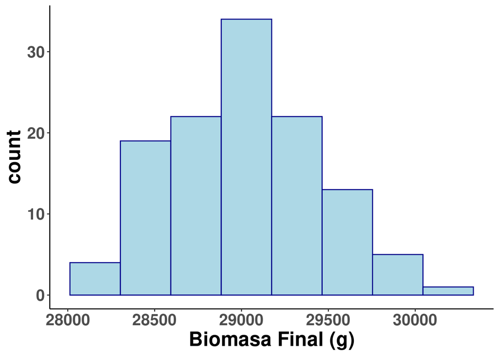

```r
ggplot(pargo_data, aes(x=Final_Biomass_g))+
  geom_histogram(color="darkblue", fill="lightblue", bins = 8)+theme_classic()+theme(text = element_text(size=20,face="bold",colour="black"))+xlab("Biomasa Final (g)")
```

**d).** Realice el exploratorio de los datos

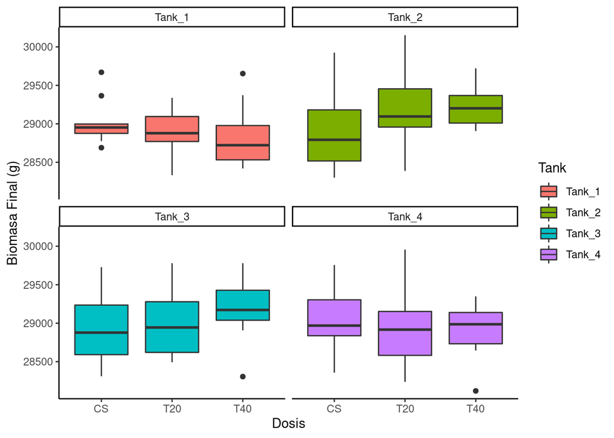

```r
ggplot(data = pargo_data,aes(x= Dosis, y = Final_Biomass_g, fill=Tank)) +
  geom_boxplot() + theme(legend.position = 'right')+ theme_classic()+ylab("Biomasa Final (g)")+facet_wrap(~ Tank)
```

### **Ejercicio 3.** Modelo de efectos fijos

**a).** Ajuste un modelo donde la variable respuesta sea **Final_Biomass_g** y como efectos fijos del modelo las variables *Dosis*, *Tank* y el término de interacción *Dosis:Tank*. Use la función **lm()**, **summary()**.

Interprete los resultados del modelo ajustado y responda las siguientes preguntas:  
- ¿El efecto fijo Dosis es estadísticamente significativo? - ¿El efecto fijo Tank es estadísticamente significativo? - ¿El efecto de interacción Dosis:Tank es estadísticamente significativo? - ¿Cuál es la bondad de ajuste del modelo $R^2$ ajustado?

```r
mod.1 <- lm(Final_Biomass_g ~ Dosis + Tank + Dosis:Tank, data = pargo_data)

pander::pander(summary(mod.1), caption = "Modelo de efectos fijos con interacción de los datos pargo_data")
```

|  | Estimate | Std. Error | t value | Pr(>\|t\|) |
| --- | --- | --- | --- | --- |
| **(Intercept)** | 29017 | 132.3 | 219.3 | 6.462e-145 |
| **DosisT20** | -145.3 | 187.1 | -0.7764 | 0.4392 |
| **DosisT40** | -178.2 | 187.1 | -0.9522 | 0.3431 |
| **TankTank_2** | -118.7 | 187.1 | -0.6343 | 0.5272 |
| **TankTank_3** | -83.7 | 187.1 | -0.4472 | 0.6556 |
| **TankTank_4** | 4.4 | 187.1 | 0.02351 | 0.9813 |
| **DosisT20:TankTank_2** | 429.2 | 264.7 | 1.622 | 0.1078 |
| **DosisT40:TankTank_2** | 521.6 | 264.7 | 1.971 | 0.05131 |
| **DosisT20:TankTank_3** | 220.2 | 264.7 | 0.832 | 0.4072 |
| **DosisT40:TankTank_3** | 417.2 | 264.7 | 1.576 | 0.1179 |
| **DosisT20:TankTank_4** | 32.3 | 264.7 | 0.122 | 0.9031 |
| **DosisT40:TankTank_4** | 54.9 | 264.7 | 0.2074 | 0.8361 |

Modelo de efectos fijos con interacción de los datos pargo_data

| Observations | Residual Std. Error | $R^2$ | Adjusted $R^2$ |
| --- | --- | --- | --- |
| 120 | 418.5 | 0.09482 | 0.002629 |

**OTRA FORMA DE VER LOS RESULTADOS DEL SUMMARY CON FORMATO TABLA DE HTML**

```r
# PARA HACER TABLA CON RESULTADOS DEL OBJETO mod.1
tab_model(mod.1, show.se = TRUE, show.aic=TRUE)
```

|  | Final_Biomass_g |  |  |  |
| --- | --- | --- | --- | --- |
| Predictors | Estimates | std. Error | CI | p |
| (Intercept) | 29017.00 | 132.33 | 28754.69 – 29279.31 | **<0.001** |
| Dosis [T20] | -145.30 | 187.15 | -516.26 – 225.66 | 0.439 |
| Dosis [T40] | -178.20 | 187.15 | -549.16 – 192.76 | 0.343 |
| Tank [Tank 2] | -118.70 | 187.15 | -489.66 – 252.26 | 0.527 |
| Tank [Tank 3] | -83.70 | 187.15 | -454.66 – 287.26 | 0.656 |
| Tank [Tank 4] | 4.40 | 187.15 | -366.56 – 375.36 | 0.981 |
| Dosis [T20] * Tank [Tank 2] | 429.20 | 264.66 | -95.41 – 953.81 | 0.108 |
| Dosis [T40] * Tank [Tank 2] | 521.60 | 264.66 | -3.01 – 1046.21 | 0.051 |
| Dosis [T20] * Tank [Tank 3] | 220.20 | 264.66 | -304.41 – 744.81 | 0.407 |
| Dosis [T40] * Tank [Tank 3] | 417.20 | 264.66 | -107.41 – 941.81 | 0.118 |
| Dosis [T20] * Tank [Tank 4] | 32.30 | 264.66 | -492.31 – 556.91 | 0.903 |
| Dosis [T40] * Tank [Tank 4] | 54.90 | 264.66 | -469.71 – 579.51 | 0.836 |
| Observations | 120 |  |  |  |
| R<sup>2</sup> / R<sup>2</sup> adjusted | 0.095 / 0.003 |  |  |  |
| AIC | 1802.688 |  |  |  |

### **Ejercicio 4.** Modelo lineal mixto

**a).** Ajuste un modelo donde la variable respuesta sea **Final_Biomass_g**, como efectos fijos del modelo las variables *Dosis*, *Tank*, el término de interacción *Dosis:Tank* y como efecto aleatorio **Family**. Use la función **lmer()**, **summary()**.

```r
mod.2 <- lmer(Final_Biomass_g ~ Dosis + Tank + Dosis:Tank + (1|Family), data = pargo_data)
summary(mod.2)
```

```
## Linear mixed model fit by REML ['lmerMod']
## Formula: Final_Biomass_g ~ Dosis + Tank + Dosis:Tank + (1 | Family)
##    Data: pargo_data
##
## REML criterion at convergence: 1638
##
## Scaled residuals:
##      Min       1Q   Median       3Q      Max
## -2.07016 -0.60637 -0.07802  0.65733  2.50340
##
## Random effects:
##  Groups   Name        Variance Std.Dev.
##  Family   (Intercept)    968    31.11
##  Residual             175118   418.47
## Number of obs: 120, groups:  Family, 6
##
## Fixed effects:
##                     Estimate Std. Error t value
## (Intercept)          29017.0      135.9 213.454
## DosisT20              -145.3      187.1  -0.776
## DosisT40              -178.2      192.2  -0.927
## TankTank_2            -118.7      192.2  -0.617
## TankTank_3             -83.7      192.2  -0.435
## TankTank_4               4.4      192.2   0.023
## DosisT20:TankTank_2    429.2      268.3   1.600
## DosisT40:TankTank_2    521.6      275.4   1.894
## DosisT20:TankTank_3    220.2      264.7   0.832
## DosisT40:TankTank_3    417.2      271.9   1.534
## DosisT20:TankTank_4     32.3      268.3   0.120
## DosisT40:TankTank_4     54.9      271.9   0.202
##
## Correlation of Fixed Effects:
##             (Intr) DssT20 DssT40 TnkT_2 TnkT_3 TnkT_4 DT20:TT_2 DT40:TT_2
## DosisT20    -0.688
## DosisT40    -0.707  0.487
## TankTank_2  -0.707  0.487  0.526
## TankTank_3  -0.707  0.487  0.500  0.500
## TankTank_4  -0.707  0.487  0.500  0.500  0.500
## DssT20:TT_2  0.480 -0.698 -0.358 -0.698 -0.340 -0.340
## DssT40:TT_2  0.494 -0.340 -0.716 -0.716 -0.349 -0.349  0.513
## DssT20:TT_3  0.487 -0.707 -0.344 -0.344 -0.688 -0.344  0.493     0.240
## DssT40:TT_3  0.500 -0.344 -0.707 -0.372 -0.707 -0.335  0.253     0.507
## DssT20:TT_4  0.480 -0.698 -0.340 -0.340 -0.340 -0.698  0.487     0.237
## DssT40:TT_4  0.500 -0.344 -0.707 -0.372 -0.354 -0.707  0.253     0.507
##             DT20:TT_3 DT40:TT_3 DT20:TT_4
## DosisT20
## DosisT40
## TankTank_2
## TankTank_3
## TankTank_4
## DssT20:TT_2
## DssT40:TT_2
## DssT20:TT_3
## DssT40:TT_3  0.487
## DssT20:TT_4  0.493     0.227
## DssT40:TT_4  0.243     0.487     0.507
```

**OTRA FORMA DE VER LOS RESULTADOS DEL SUMMARY CON FORMATO TABLA DE HTML**

|  | Final_Biomass_g |  |  |  |
| --- | --- | --- | --- | --- |
| Predictors | Estimates | std. Error | CI | p |
| (Intercept) | 29017.00 | 135.94 | 28747.85 – 29286.15 | **<0.001** |
| Dosis [T20] | -145.30 | 187.15 | -516.26 – 225.66 | 0.439 |
| Dosis [T40] | -178.20 | 192.25 | -558.83 – 202.43 | 0.356 |
| Tank [Tank 2] | -118.70 | 192.25 | -499.33 – 261.93 | 0.538 |
| Tank [Tank 3] | -83.70 | 192.25 | -464.33 – 296.93 | 0.664 |
| Tank [Tank 4] | 4.40 | 192.25 | -376.23 – 385.03 | 0.982 |
| Dosis [T20] * Tank [Tank 2] | 429.20 | 268.30 | -102.29 – 960.69 | 0.112 |
| Dosis [T40] * Tank [Tank 2] | 521.60 | 275.42 | -23.42 – 1066.62 | 0.061 |
| Dosis [T20] * Tank [Tank 3] | 220.20 | 264.66 | -304.41 – 744.81 | 0.407 |
| Dosis [T40] * Tank [Tank 3] | 417.20 | 271.88 | -121.09 – 955.49 | 0.128 |
| Dosis [T20] * Tank [Tank 4] | 32.30 | 268.30 | -499.19 – 563.79 | 0.904 |
| Dosis [T40] * Tank [Tank 4] | 54.90 | 271.88 | -483.39 – 593.19 | 0.840 |
| Random Effects |  |  |  |  |
| σ<sup>2</sup> | 175117.88 |  |  |  |
| τ<sub>00</sub> <sub>Family</sub> | 968.04 |  |  |  |
| ICC | 0.01 |  |  |  |
| N <sub>Family</sub> | 6 |  |  |  |
| Observations | 120 |  |  |  |
| Marginal R<sup>2</sup> / Conditional R<sup>2</sup> | 0.086 / 0.091 |  |  |  |
| AIC | 1666.029 |  |  |  |

### **Ejercicio 5.** Comparación y selección de modelos

**a).** Realice la comparación de modelos con la función AIC().

- ¿Cuál es el mejor modelo?
- ¿Hubo mejoría al incorporar el efecto aleatorio de familia?

```r
AIC(mod.1, mod.2)
```

```
##       df      AIC
## mod.1 13 1802.688
## mod.2 14 1666.029
```